None

# NGS: SNP calling, genoptype calling and Imputation

We will be looking at the default behaviour for 3 different programs.

| tool | SAMtools/bcftools | GATK | ANGSD |
| --- | --- | --- | --- |
| Genotype likelihood | tries to model error dependencies | simple | user specified |
| SNP caller | uses SFS as prior | uses SFS as prior | likelihood ratio test |
| Genotype caller | MAF | ML | MAF prior |

All the programs have additional filters and additional differences.

## Setup

We are first going to set up the environmental variables to help run the software later.

```
# shared tools and data folder
TOOL_PATH=/course/popgen25/software
RESOURCE_PATH=/course/popgen25/Imputation/resources
INPUT_PATH=/course/popgen25/Imputation  # for input data
```

```
# go to working folder
cd ~/
mkdir -p ~/imputation
cd imputation
OUT_DIR=~/imputation
```

```
# set R working space
wd <- path.expand("~/imputation")
setwd(wd)
```

We should have access to all files and tools if the environment is set up correctly - make sure that there are no errors in the output of the next cell.

```
# check environment
which angsd
which samtools
which bcftools
which vcftools

# Additional tools
BEAGLE4=${TOOL_PATH}/beagle.27Jan18.7e1.jar
BEAGLE5=${TOOL_PATH}/beagle.27Feb25.75f.jar
QUILT2=${TOOL_PATH}/QUILT/QUILT2.R

# Reference data
QUILT2_MAP=${RESOURCE_PATH}/CEU-chr20-final.b38.txt.gz
BEAGLE5_MAP=${RESOURCE_PATH}/plink.chr20.GRCh38.rename.map
REF_GENOME=${RESOURCE_PATH}/GRCh38_full_analysis_set_plus_decoy_hla.fa

REF_VCF=${INPUT_PATH}/vcfs/CEU_ref_set.chr20.vcf.gz
TRUE_VCF=${INPUT_PATH}/vcfs/CEU_true_set.chr20.vcf.gz
EXAMPLE_VCF=${INPUT_PATH}/vcfs/example.vcf.gz
QUILT2_EXAMPLE=${INPUT_PATH}/vcfs/quilt2_all_inds.vcf.gz

# Input data
SAM_FOLDER=${INPUT_PATH}/bams
FAKE_SNPCHIP=${INPUT_PATH}/vcfs/CEU_fake_chip.chr20.vcf.gz

# you could run this to check whether files exist
ls ${BEAGLE4} ${BEAGLE5} ${BEAGLE5_MAP} ${QUILT2} ${QULT2_MAP} ${REF_GENOME} ${TRUE_VCF} ${REF_VCF} ${QUILT2_EXAMPLE} ${FAKE_SNPCHIP} ${SAM_FOLDER}
```

```
/usr/local/bin/angsd
/usr/bin/samtools
/usr/bin/bcftools
/usr/bin/vcftools
/course/popgen25/Imputation/resources/GRCh38_full_analysis_set_plus_decoy_hla.fa
/course/popgen25/Imputation/resources/plink.chr20.GRCh38.rename.map
/course/popgen25/Imputation/vcfs/CEU_fake_chip.chr20.vcf.gz
/course/popgen25/Imputation/vcfs/CEU_ref_set.chr20.vcf.gz
/course/popgen25/Imputation/vcfs/CEU_true_set.chr20.vcf.gz
/course/popgen25/Imputation/vcfs/quilt2_all_inds.vcf.gz
/course/popgen25/software/beagle.27Feb25.75f.jar
/course/popgen25/software/beagle.27Jan18.7e1.jar
/course/popgen25/software/QUILT/QUILT2.R

/course/popgen25/Imputation/bams:
NA07000.lc.bam      NA11892.lc.bam.bai  NA12156.lc.bam      NA12827.lc.bam.bai
NA07000.lc.bam.bai  NA11930.lc.bam      NA12156.lc.bam.bai  NA12828.lc.bam
NA07048.lc.bam      NA11930.lc.bam.bai  NA12272.lc.bam      NA12828.lc.bam.bai
NA07048.lc.bam.bai  NA11931.lc.bam      NA12272.lc.bam.bai  NA12829.lc.bam
NA07056.lc.bam      NA11931.lc.bam.bai  NA12340.lc.bam      NA12829.lc.bam.bai
NA07056.lc.bam.bai  NA11992.lc.bam      NA12340.lc.bam.bai  NA12842.lc.bam
NA10851.lc.bam      NA11992.lc.bam.bai  NA12348.lc.bam      NA12842.lc.bam.bai
NA10851.lc.bam.bai  NA11994.lc.bam      NA12348.lc.bam.bai  NA12872.lc.bam
NA11829.lc.bam      NA11994.lc.bam.bai  NA12718.lc.bam      NA12872.lc.bam.bai
NA11829.lc.bam.bai  NA12043.lc.bam      NA12718.lc.bam.bai  NA12878.lc.bam
NA11832.lc.bam      NA12043.lc.bam.bai  NA12749.lc.bam      NA12878.lc.bam.bai
NA11832.lc.bam.bai  NA12044.lc.bam      NA12749.lc.bam.bai  NA12889.lc.bam
NA11881.lc.bam      NA12044.lc.bam.bai  NA12813.lc.bam      NA12889.lc.bam.bai
NA11881.lc.bam.bai  NA12046.lc.bam      NA12813.lc.bam.bai  NA12890.lc.bam
NA11892.lc.bam      NA12046.lc.bam.bai  NA12827.lc.bam      NA12890.lc.bam.bai
```

## Input formats and data preparation

### Input Reference panel

IMPUTE format hap and legend format files with reference haplotypes. These can be made from haplotype VCFs using bcftools convert --haplegendsample. Alternatively, they can be made manually. The haplotype file is a gzipped file with no header and no rownames, with one row per SNP, with one column per reference haplotype, space separated, and values of 0 (ref) and 1 (alt). The legend file is a gzipped file with no rownames, a header file including position for the physical position in 1 based coordinates, a0 for the reference allele, and a1 for the alternate allele. An optional sample file and file with samples to exclude can be useful for changing who is used in the reference panel.

### Genetic map

This is sometimes referred to as recombiation map. File with genetic map information, with 3 white-space delimited columns giving position (1-based), recombination rate in cM/Mbp, and genetic map in cM

### Bams

Given as a bamlist (i.e. a file with one row per sample, the path to the bam)

### Truth data (Optional)

Consists of two files - phasefile and posfile - these are useful for understanding performance of imputation.

Phasefile has a header row with a name for each sample, matching what is found in the bam file. File is tab separated, one subject per column, with 0 = ref and 1 = alt, separated by a vertical bar |, e.g. 0|0 or 0|1. Note therefore this file has one more row than posfile which has no header.

For posfile, this is a file with positions of where to impute, lining up one-to-one with the SNPs of phasefile. File is tab seperated with no header, one row per SNP, with col 1 = chromosome, col 2 = physical position (sorted from smallest to largest), col 3 = reference base, col 4 = alternate base. Bases are capitalized. Example first row: 1 1000 A G

- Prepare input files - list of bams.

```
ls $SAM_FOLDER/NA*.bam > ${OUT_DIR}/CEU_inds_bams.list
```

- Check your data to see it looks OK.

```
samtools mpileup -b ${OUT_DIR}/CEU_inds_bams.list | head -n 10
```

```
[mpileup] 30 samples in 30 input files
chr20	1999852	N	1	^]a	?	0	*	*	0	*	*	0	*	*	0	*	*	0	*	*	0	*	*	0	*	*	0	*	*	0	*	*	0	*	*	0	*	*	0	*	*	0	*	*	0	*	*	0	*	*	0	*	*	0	*	*	0	*	*	0	*	*	0	*	*	0	*	*	0	*	*	0	*	*	0	*	*	0	*	*	0	*	*	0	*	*	0	*	*	0	*	*
chr20	1999853	N	1	c	?	0	*	*	0	*	*	0	*	*	1	^]c	?	0	*	*	0	*	*	0	*	*	0	*	*	0	*	*	0	*	*	0	*	*	0	*	*	0	*	*	0	*	*	0	*	*	0	*	*	0	*	*	0	*	*	0	*	*	0	*	*	0	*	*	0	*	*	0	*	*	0	*	*	0	*	*	0	*	*	0	*	*	0	*	*	0	*	*
chr20	1999854	N	1	a	?	0	*	*	0	*	*	0	*	*	1	a	?	0	*	*	0	*	*	0	*	*	0	*	*	0	*	*	0	*	*	0	*	*	0	*	*	0	*	*	0	*	*	0	*	*	0	*	*	0	*	*	0	*	*	0	*	*	0	*	*	0	*	*	0	*	*	0	*	*	0	*	*	0	*	*	0	*	*	0	*	*	0	*	*	0	*	*
chr20	1999855	N	1	t	?	0	*	*	0	*	*	0	*	*	1	t	?	0	*	*	0	*	*	0	*	*	0	*	*	0	*	*	0	*	*	0	*	*	0	*	*	0	*	*	0	*	*	0	*	*	0	*	*	0	*	*	0	*	*	0	*	*	0	*	*	0	*	*	0	*	*	0	*	*	0	*	*	0	*	*	0	*	*	0	*	*	0	*	*	0	*	*
chr20	1999856	N	1	a	?	0	*	*	0	*	*	0	*	*	1	a	?	0	*	*	0	*	*	0	*	*	0	*	*	0	*	*	0	*	*	0	*	*	0	*	*	0	*	*	0	*	*	0	*	*	0	*	*	0	*	*	0	*	*	0	*	*	0	*	*	0	*	*	0	*	*	0	*	*	0	*	*	0	*	*	0	*	*	0	*	*	0	*	*	0	*	*
chr20	1999857	N	1	t	?	0	*	*	0	*	*	0	*	*	1	t	?	0	*	*	0	*	*	1	^]t	?	0	*	*	0	*	*	0	*	*	0	*	*	0	*	*	0	*	*	0	*	*	0	*	*	0	*	*	0	*	*	0	*	*	0	*	*	0	*	*	0	*	*	0	*	*	0	*	*	0	*	*	0	*	*	0	*	*	1	^]t	?	0	*	*	0	*	*
chr20	1999858	N	1	a	?	0	*	*	0	*	*	0	*	*	1	a	?	0	*	*	0	*	*	1	a	?	0	*	*	0	*	*	0	*	*	0	*	*	0	*	*	0	*	*	0	*	*	0	*	*	0	*	*	0	*	*	0	*	*	0	*	*	0	*	*	0	*	*	0	*	*	0	*	*	0	*	*	0	*	*	0	*	*	1	a	?	0	*	*	0	*	*
chr20	1999859	N	1	c	?	0	*	*	0	*	*	0	*	*	1	c	?	0	*	*	0	*	*	1	c	?	0	*	*	0	*	*	0	*	*	0	*	*	0	*	*	0	*	*	0	*	*	0	*	*	0	*	*	0	*	*	0	*	*	0	*	*	0	*	*	1	^]C	?	0	*	*	0	*	*	0	*	*	0	*	*	0	*	*	1	c	?	0	*	*	0	*	*
chr20	1999860	N	1	a	?	0	*	*	0	*	*	0	*	*	1	a	?	0	*	*	0	*	*	1	a	?	0	*	*	0	*	*	0	*	*	0	*	*	0	*	*	0	*	*	0	*	*	0	*	*	0	*	*	0	*	*	0	*	*	0	*	*	0	*	*	1	A	?	0	*	*	0	*	*	0	*	*	0	*	*	0	*	*	1	a	?	0	*	*	0	*	*
chr20	1999861	N	1	c	?	0	*	*	0	*	*	0	*	*	1	c	?	0	*	*	0	*	*	1	c	?	0	*	*	1	^]C	?	0	*	*	0	*	*	0	*	*	0	*	*	0	*	*	0	*	*	0	*	*	0	*	*	0	*	*	0	*	*	0	*	*	1	C	?	0	*	*	0	*	*	0	*	*	0	*	*	0	*	*	1	c	?	0	*	*	0	*	*
```

- View the data in mpileup format and identify the columns

And you should index the fasta reference

```
## do not run. This is done for you
#samtools faidx $REF
```

## Output formats

Output VCF with both SNP annotation information (see below) and per-sample genotype information.

Per-sample genotype information includes the following entries:

- GT: Phased genotypes. Genotypes with phase where each allele is the rounded per-haplotype posterior probability (HD below).
- GP: Genotype posteriors. Posterior probabilities of the three genotypes given the data.
- DS: Diploid dosage. Posterior expectation of the diploid genotype i.e. the expected number of copies of the alternate allele
- HD: Haploid dosages. Per-haplotype posterior probability of an alternate allele

Note that in QUILT, genotype posteriors (GP) and dosages (DS) are taken from the main Gibbs sampling, while the phasing results (GT and HD) are taken from an additional special phasing Gibbs sample. As such, phasing results (GT and HD) might not be consistent with genotype information (GP and DS). If consistency is necessary, note that you can create a consistent GP and DS from HD.

```
zcat ${EXAMPLE_VCF} | head -n 100 | tail -n +95
```

```
chr20	2003453	.	A	C	.	PASS	EAF=0.001;INFO_SCORE=1;HWE=1.00e+00;ERC=0.03567;EAC=106.893;PAF=0.00033	GT:GP:DS:HD	0|0:0.998,0.002,0.000:0.002:0.001,0.001	0|0:0.998,0.002,0.000:0.002:0.001,0.001	0|0:0.998,0.002,0.000:0.002:0.001,0.001	0|0:0.998,0.002,0.000:0.002:0.001,0.001	0|0:0.998,0.002,0.000:0.002:0…
chr20	2003539	.	C	T	.	PASS	EAF=0.001;INFO_SCORE=1;HWE=1.00e+00;ERC=0.03867;EAC=115.884;PAF=0.00033	GT:GP:DS:HD	0|0:0.998,0.002,0.000:0.002:0.001,0.001	0|0:0.998,0.002,0.000:0.002:0.001,0.001	0|0:0.998,0.002,0.000:0.002:0.001,0.001	0|0:0.998,0.002,0.000:0.002:0.001,0.001	0|0:0.998,0.002,0.000:0.002:0…
chr20	2003625	.	C	T	.	PASS	EAF=0.001;INFO_SCORE=1;HWE=1.00e+00;ERC=0.03633;EAC=108.891;PAF=0.00033	GT:GP:DS:HD	0|0:0.998,0.002,0.000:0.002:0.001,0.001	0|0:0.998,0.002,0.000:0.002:0.001,0.001	0|0:0.998,0.002,0.000:0.002:0.001,0.001	0|0:0.998,0.002,0.000:0.002:0.001,0.001	0|0:0.998,0.002,0.000:0.002:0…
chr20	2003664	.	T	A	.	PASS	EAF=0.001;INFO_SCORE=1;HWE=1.00e+00;ERC=0.04;EAC=110.88;PAF=0.00036	GT:GP:DS:HD	0|0:0.998,0.002,0.000:0.002:0.001,0.001	0|0:0.998,0.002,0.000:0.002:0.001,0.001	0|0:0.998,0.002,0.000:0.002:0.001,0.001	0|0:0.998,0.002,0.000:0.002:0.001,0.001	0|0:0.998,0.002,0.000:0.002:0.001…
chr20	2003678	.	T	C	.	PASS	EAF=0.00112;INFO_SCORE=1;HWE=1.00e+00;ERC=0.04033;EAC=111.879;PAF=0.00036	GT:GP:DS:HD	0|0:0.998,0.002,0.000:0.002:0.001,0.001	0|0:0.995,0.005,0.000:0.005:0.001,0.001	0|0:0.998,0.002,0.000:0.002:0.001,0.001	0|0:0.998,0.002,0.000:0.002:0.001,0.001	0|0:0.998,0.002,0.000:0.002…
chr20	2003696	.	C	A	.	PASS	EAF=0.001;INFO_SCORE=1;HWE=1.00e+00;ERC=0.03867;EAC=115.884;PAF=0.00033	GT:GP:DS:HD	0|0:0.998,0.002,0.000:0.002:0.001,0.001	0|0:0.998,0.002,0.000:0.002:0.001,0.001	0|0:0.998,0.002,0.000:0.002:0.001,0.001	0|0:0.998,0.002,0.000:0.002:0.001,0.001	0|0:0.998,0.002,0.000:0.002:0…
gzip: 01,0.001	0|0:0.998,0.002,0.000:0.002:0.001,0.001	0|0:0.998,0.002,0.000:0.002:0.001,0.001	0|0:0.998,0.002,0.000:0.002:0.001,0.001	0|0:0.998,0.002,0.000:0.002:0.001,0.001	0|0:0.998,0.002,0.000:0.002:0.001,0.001	0|0:0.998,0.002,0.000:0.002:0.001,0.001	0|0:0.998,0.002,0.000:0.002:0.001,0.001	0|0:0…
stdout: Broken pipe
```

## Genotype calling without Imputation

In this exercise you will try to generate the widely used **vcf** formatted files. We will use

- angsd
- bcftools
- vcftools

### samtools/bcftools

SAMtools outputs a binary version of vcf files, called bcf files. To get a the vcf equivalent you shou0ld pipe the data to bcftools which is located within the samtools/bcftools subfolder.

bcftools can do single sample genotyping/SNP calling however, it calculates the genotype likelihoods a little different than the simple GATK model

```
# 3 min to run
mkdir -p ${OUT_DIR}/bcftoolsgt_out

bcftools mpileup -f ${REF_GENOME} -Ou -b ${OUT_DIR}/CEU_inds_bams.list -r chr20:2000001-5000000 | \
    bcftools call -V indels -a GQ,GP -mv -Ov -o ${OUT_DIR}/bcftoolsgt_out/CEU_inds_bam.vcf

bgzip -f ${OUT_DIR}/bcftoolsgt_out/CEU_inds_bam.vcf
tabix -f ${OUT_DIR}/bcftoolsgt_out/CEU_inds_bam.vcf.gz
```

```
Note: none of --samples-file, --ploidy or --ploidy-file given, assuming all sites are diploid
[mpileup] 30 samples in 30 input files
[mpileup] maximum number of reads per input file set to -d 250
```

### ANGSD

We now call genotypes using ANGSD, and by simply calling the genotype that has the highest likelihood. We see that genotypes in the above vcf format is identified by the counts of non-reference. The default behaviour of angsd is to estimate the major/minor based on GL. But we can force it to use the reference allele as the major allele by using -doMajorMinor 4 and supplying the reference (just as is done in GATK and Samtools).

```
# 5 min to run
mkdir -p ${OUT_DIR}/angsd_out

angsd -bam ${OUT_DIR}/CEU_inds_bams.list -SNP_pval 0.001 \
 -doMaf 2 -doMajorMinor 4 -r chr20:2000001-5000000 \
 -doGlf 2 -doGeno 2 -doPost 2 -GL 1 -doBcf 1 \
 -out ${OUT_DIR}/angsd_out/angsd_genotype -ref ${REF_GENOME}

bcftools index ${OUT_DIR}/angsd_out/angsd_genotype.bcf
```

```
	-> angsd version: 0.941-21-g8a58e17 (htslib: 1.18-17-g5acbc15) build(Sep 10 2023 10:54:12)
	-> angsd -bam /home/jupyter-harvinder/imputation/CEU_inds_bams.list -SNP_pval 0.001 -doMaf 2 -doMajorMinor 4 -r chr20:2000001-5000000 -doGlf 2 -doGeno 2 -doPost 2 -GL 1 -doBcf 1 -out /home/jupyter-harvinder/imputation/angsd_out/angsd_genotype -ref /course/popgen25/Imputation/resources/GRCh38_full_a…
	-> Inputtype is BAM/CRAM
[multiReader] 30 samples in 30 input files
	-> Reading fasta: /course/popgen25/Imputation/resources/GRCh38_full_analysis_set_plus_decoy_hla.fa
	-> SNP-filter using a pvalue: 1.000000e-03 correspond to 10.827566 likelihood units

[bcfoutput] 	Please add the following parameters
		 '-gl 1 -dopost 1 -domajorminor 1 -domaf 1 -dobcf 1 --ignore-RG 0 -dogeno 1 -docounts 1'

	-> Inputtype is BAM/CRAM
	-> Parsing 30 number of samples
	-> Region lookup 1/1
	-> Printing at chr: chr20 pos:4917102 chunknumber 2200 contains 1505 sites
	-> Done reading data waiting for calculations to finish
	-> Done waiting for threads
	-> Output filenames:
		->"/home/jupyter-harvinder/imputation/angsd_out/angsd_genotype.arg"
		->"/home/jupyter-harvinder/imputation/angsd_out/angsd_genotype.beagle.gz"
		->"/home/jupyter-harvinder/imputation/angsd_out/angsd_genotype.mafs.gz"
		->"/home/jupyter-harvinder/imputation/angsd_out/angsd_genotype.geno.gz"
		->"/home/jupyter-harvinder/imputation/angsd_out/angsd_genotype.bcf"
	-> Tue Aug  5 10:09:07 2025
	-> Arguments and parameters for all analysis are located in .arg file
	-> Total number of sites analyzed: 3000280
	-> Number of sites retained after filtering: 11255
	[ALL done] cpu-time used =  308.20 sec
	[ALL done] walltime used =  309.00 sec
```

Take a look at the command here, and figure out what ANGSD is doing to identify variants and estimate genotype likelihoods and call genotypes.

For all the information on ANGSD, please view https://www.popgen.dk/angsd/index.php/ANGSD

### Comparing the results (SNP-discovery)

This requires R and the vcfppR and UpSetR package. Let us examine the difference between the two different approaches for SNP-calling, and their difference from the truth.

```
library(vcfppR)
library(UpSetR)

find_match <- function(vcf_in, vcf_truth, name="tool", data_type="gt"){
    if(! all(vcf_truth$samples %in% vcf_in$samples)){stop("samples doesn't match")}
    true_pos_match <- match(vcf_truth$pos, vcf_in$pos)
    vcf_pos_match <- match(vcf_in$pos, vcf_truth$pos)
    vcf_in[[data_type]][true_pos_match,  match(vcf_truth$samples, vcf_in$samples)]
}

gt_truth_file <- paste0("/course/popgen25/Imputation/vcfs/CEU_true_set.chr20.vcf.gz")
gt_bcftool_file <- paste0(wd, "/bcftoolsgt_out/CEU_inds_bam.vcf.gz")
gt_angsd_file <- paste0(wd, "/angsd_out/angsd_genotype.bcf")

res_truth <- vcftable(gt_truth_file, "chr20:2000001-5000000", vartype = "snps")
res_bcftools <- vcftable(gt_bcftool_file, "chr20:2000001-5000000", vartype = "snps")
res_angsd <- vcftable(gt_angsd_file, "chr20:2000001-5000000", vartype = "snps")
```

We will use Upset plot to see the performance of angsd and bcftools variant calling. Here we are only checking if the variant positions are being found as variant in the different calling strategies.

```
## Make the data frame to make the upset plot.
upsetdf <- fromList(list(
    Truth=res_truth$pos,
    angsd=res_angsd$pos,
    bcftools=res_bcftools$pos
))

## Visualize the results
upset(
  upsetdf,
  order.by         = "freq",
  sets.x.label     = "SNP count",
  mainbar.y.label  = "shared SNP",
  text.scale = c(2.2, 1.8, 2.2, 1.8, 2, 1.8)
)
```

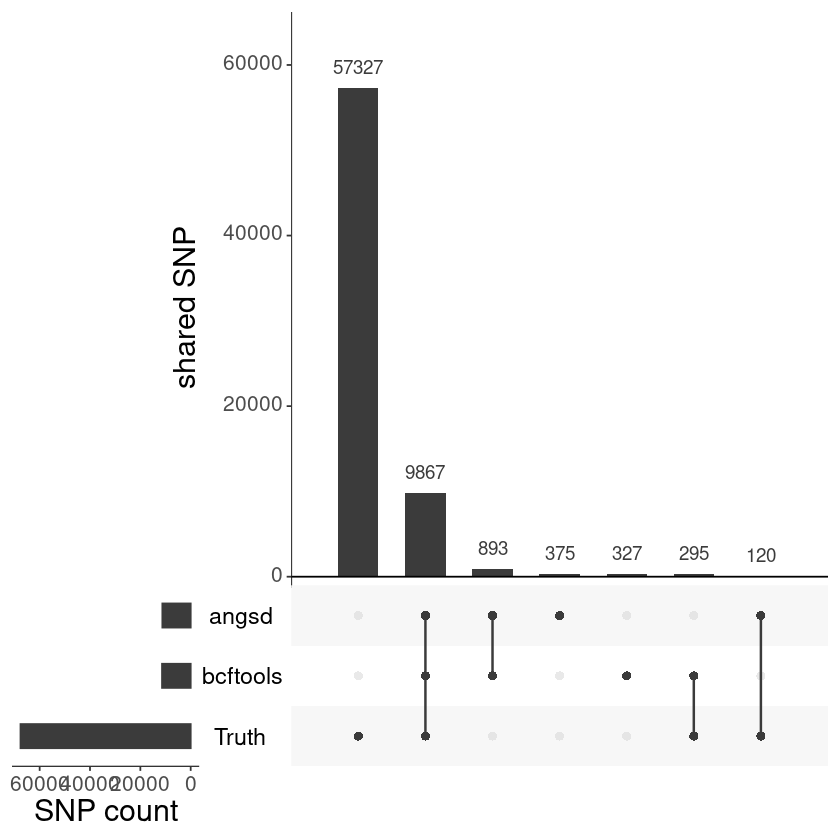

See the last two columns, angsd has a bit less shared SNPs with the truth. The reason is, angsd is mainly focusing on genotype likelihood estimation, but not genotype calling.

What else would you like to know to evaluate the performance of the genotype calling methods?

# Genotype calling with imputation

We will use several different strategies to impute the genotype.

## Imputation using Beagle 4

We should first preparing the information needed for imputation. As we already have genotype (likelihood) data called by angsd, we will just use those output files.

Before that, we need to convert the data to vcf format, and build index, which is required for running Beagle 4 in genotype (likelihood) mode.

```
# prepare data for beagle 4, using angsd bcf output
mkdir -p ${OUT_DIR}/beagle4_out
bcftools view ${OUT_DIR}/angsd_out/angsd_genotype.bcf -Ov -o ${OUT_DIR}/beagle4_out/angsd_for_beagle.vcf
bgzip -f ${OUT_DIR}/beagle4_out/angsd_for_beagle.vcf
tabix -f ${OUT_DIR}/beagle4_out/angsd_for_beagle.vcf.gz
```

Run the imputation based on the angsd genotype likelihoods. Here, `gl` stands for genotype likelihoods.

```
# 10 secs to run
java -Xmx8g -jar ${BEAGLE4} \
    gl=${OUT_DIR}/beagle4_out/angsd_for_beagle.vcf.gz \
    out=${OUT_DIR}/beagle4_out/beagle4_imputation \
    niterations=10 \
    nthreads=32
bcftools index ${OUT_DIR}/beagle4_out/beagle4_imputation.vcf.gz
```

```
beagle.27Jan18.7e1.jar (version 4.1)
Copyright (C) 2014-2015 Brian L. Browning
Enter "java -jar beagle.27Jan18.7e1.jar" for a summary of command line arguments.
Start time: 10:10 AM CEST on 05 Aug 2025

Command line: java -Xmx8192m -jar beagle.jar
  gl=/home/jupyter-harvinder/imputation/beagle4_out/angsd_for_beagle.vcf.gz
  out=/home/jupyter-harvinder/imputation/beagle4_out/beagle4_imputation
  niterations=10
  nthreads=32

No genetic map is specified: using 1 cM = 1 Mb

reference samples:       0
target samples:         30

Window 1 [ chr20:2000377-4999859 ]
target markers:      11255

Starting burn-in iterations

Window=1 Iteration=1
Time for building model:         0 seconds
Time for sampling (singles):     0 seconds
DAG statistics
mean edges/level: 4      max edges/level: 11
mean edges/node:  1.947  mean count/edge: 15

Window=1 Iteration=2
Time for building model:         0 seconds
Time for sampling (singles):     0 seconds
DAG statistics
mean edges/level: 5      max edges/level: 12
mean edges/node:  1.819  mean count/edge: 12

Window=1 Iteration=3
Time for building model:         1 second
Time for sampling (singles):     0 seconds
DAG statistics
mean edges/level: 6      max edges/level: 12
```

[output cut: 115 more lines]

```

Window=1 Iteration=20
Time for building model:         0 seconds
Time for sampling (singles):     0 seconds
DAG statistics
mean edges/level: 11     max edges/level: 20
mean edges/node:  1.073  mean count/edge: 5

Number of markers:               11255
Total time for building model: 8 seconds
Total time for sampling:       6 seconds
Total run time:                16 seconds

End time: 10:10 AM CEST on 05 Aug 2025
beagle.27Jan18.7e1.jar (version 4.1) finished
```

What is the reference panel for the imputation here? What is beagle4 doing? Why is doing this better than just using the genotype likelihoods or genotypes?

## Imputation using QUILT2

We will then use QUILT2 to go all the way from bams to genotypes with imputation, i.e. it will start from the bam file, do genotype calling and perform imputation.

Because of time constraints, we will take 1 sample as an example, and use the prepared outcome of 30 samples for further comparison.

```
# 2 min to run
mkdir -p ${OUT_DIR}/quilt2_1_ind

head -n 1 ${OUT_DIR}/CEU_inds_bams.list > ${OUT_DIR}/CEU_1_ind.list
$QUILT2 \
    --outputdir=${OUT_DIR}/quilt2_1_ind \
    --chr=chr20 \
    --regionStart=2000001 \
    --regionEnd=5000000 \
    --buffer=500000 \
    --nGen=100 \
    --bamlist=${OUT_DIR}/CEU_1_ind.list \
    --genetic_map_file=${QUILT2_MAP} \
    --reference_vcf_file=${REF_VCF} \
    --save_prepared_reference=TRUE
```

```
[2025-08-05 10:00:29] Running QUILT(outputdir = /home/jupyter-harvinder/imputation/quilt2_1_ind, chr = chr20, method = diploid, regionStart = 2000001, regionEnd = 5000000, buffer = 500000, fflist = , bamlist = /home/jupyter-harvinder/imputation/CEU_1_ind.list, cramlist = , sampleNames_file = , refer…
[2025-08-05 10:00:29] Auto-set n_burn_in_seek_its to 2 i.e. only sample one dosage per Gibbs sample
[2025-08-05 10:00:29] Processing reference information
[2025-08-05 10:00:29] Running QUILT_prepare_reference(outputdir = /home/jupyter-harvinder/imputation/quilt2_1_ind, chr = chr20, nGen = 100, regionStart = 2000001, regionEnd = 5000000, buffer = 500000, output_file = /home/jupyter-harvinder/imputation/quilt2_1_ind/RData/QUILT_prepared_reference.chr20.…
[2025-08-05 10:00:29] Program start
[2025-08-05 10:00:29] Begin converting reference haplotypes
[2025-08-05 10:00:29] Using reference information from:/course/popgen25/Imputation/vcfs/CEU_ref_set.chr20.vcf.gz
[2025-08-05 10:00:29] Using strategy of first imputing using common SNPs and then using all SNPs, with allele frequency threshold:0.001
[2025-08-05 10:00:29] Begin get sites and haplotypes from reference vcf
[2025-08-05 10:01:15] End get sites and haplotypes from reference vcf
[2025-08-05 10:01:15] There were 12179 skipped variants when processing the reference VCF (not bi-allelic, not a SNP, not unique position
[2025-08-05 10:01:15] There are 0 common and 0 rare (0 total) variants in the left buffer region 1500001 <= position < 2000001
[2025-08-05 10:01:15] There are 14191 common and 53418 rare (67609 total) variants in the central region 2000001 <= position <= 5000000
[2025-08-05 10:01:15] There are 0 common and 0 rare (0 total) variants in the right buffer region 5000000 < position <= 5500000
[2025-08-05 10:01:15] Getting and validating genetic map
[2025-08-05 10:01:20] Match genetic map to desired imputation positions
[2025-08-05 10:01:20] Done with getting genetic map
[2025-08-05 10:01:26] There are 59 regions out of 443 below minimum recombination rate, setting them to minimum rate
[2025-08-05 10:01:26] There are 0 regions out of 443 above maximum recombination rate, setting them to maximum rate
[2025-08-05 10:01:26] Using nMaxDH = 43
[2025-08-05 10:01:26] Build mspbwt indices
[2025-08-05 10:01:26] Done building mspbwt indices
[2025-08-05 10:01:26] Save converted reference haplotypes
[2025-08-05 10:01:26] Done converting reference haplotypes
[2025-08-05 10:01:26] Done processing reference information
[2025-08-05 10:01:26] Overriding default parameters for small reference panel
[2025-08-05 10:01:26] Observing number of reference haplotypes K=138
[2025-08-05 10:01:26] Reset n_seek_its from 3 to 1
[2025-08-05 10:01:26] Reset n_burn_in_seek_its from 2 to 0
[2025-08-05 10:01:26] Set Ksubset to 138 (no longer necessary)
[2025-08-05 10:01:26] Set Knew to 138 (no longer necessary)
[2025-08-05 10:01:26] Get BAM sample names
[2025-08-05 10:01:27] Done getting BAM sample names
[2025-08-05 10:01:27] There are 14191 common SNPs and 67609 SNPs overall in this region
[2025-08-05 10:01:27] There are 329 regions out of 2112 below minimum recombination rate, setting them to minimum rate
[2025-08-05 10:01:27] There are 0 regions out of 2112 above maximum recombination rate, setting them to maximum rate
[2025-08-05 10:01:27] Imputing sample: 1
[2025-08-05 10:01:29] The average depth of this sample is:3.77553712488928
[2025-08-05 10:01:29] There are 27568 reads under consideration
[2025-08-05 10:01:29] i_gibbs=1, i_it = 1 small gibbs
```

[output cut: 15 more lines]

```
[2025-08-05 10:01:50] i_gibbs=6, i_it = 1 full
[2025-08-05 10:01:50] i_gibbs=6, i_it = 1 small gibbs (all SNPs)
[2025-08-05 10:01:52] i_gibbs=7, i_it = 1 small gibbs
[2025-08-05 10:01:54] i_gibbs=7, i_it = 1 full
[2025-08-05 10:01:54] i_gibbs=7, i_it = 1 small gibbs (all SNPs)
[2025-08-05 10:01:56] There are 21 out of 135 regions that have been flipped by consensus
[2025-08-05 10:01:56] Phasing it
[2025-08-05 10:01:56] i_gibbs=8, i_it = 1 small gibbs
[2025-08-05 10:01:58] i_gibbs=8, i_it = 1 full
[2025-08-05 10:01:58] i_gibbs=8, i_it = 1 small gibbs (all SNPs)
[2025-08-05 10:02:01] Begin making and writing output file
[2025-08-05 10:02:02] bgzip output file
[2025-08-05 10:02:02] Done making and writing output file
[2025-08-05 10:02:02] Done QUILT
NULL
```

```
# it takes 20 min to run for all individuals, we will just copy the prepared results
#quilt_out=${output_dir}/quilt2_output
#if [ -d $quilt_out ]; then rm -rf $quilt_out; fi
#$QUILT2 \
#    --outputdir=${quilt_out} \
#    --chr=chr20 \
#    --regionStart=2000001 \
#    --regionEnd=5000000 \
#    --buffer=500000 \
#    --nGen=100 \
#    --bamlist=${output_dir}/CEU_inds_bams.list \
#    --genetic_map_file=${QUILT2_MAP} \
#    --reference_vcf_file=${REF_VCF} \
#    --save_prepared_reference=TRUE

cp ${QUILT2_EXAMPLE} ${OUT_DIR}/quilt2_1_ind/quilt2_all_inds.vcf.gz
tabix ${OUT_DIR}/quilt2_1_ind/quilt2_all_inds.vcf.gz
```

Carefully go over the options used here in QUILT2, and try to figure out what is different here from beagle4.

## SNP-chip data Beagle 5.5 imputation

Beagle 5.5 supports large reference panel, which should help improve the accuracy of imputation and retain more SNPs with good imputation results. To highlight the use of Beagle 5.5, we have made a SNP chip data - this is done by selecting a subset of sites from the truth file, and pretending that these sites are on the genotyping chip. We will use these together with the reference panel to get the genotypes for all the sites in the reference vcf.

```
# 3 secs to run
mkdir -p ${OUT_DIR}/beagle5_out

java -Xmx8g -jar $BEAGLE5 \
    gt=${FAKE_SNPCHIP} \
    ref=${REF_VCF} \
    map=${BEAGLE5_MAP} \
    nthreads=16 \
    impute=true \
    gp=true \
    out=${OUT_DIR}/beagle5_out/beagle5_imputed

bcftools index ${OUT_DIR}/beagle5_out/beagle5_imputed.vcf.gz
```

```
beagle.27Feb25.75f.jar (version 5.5)
Copyright (C) 2014-2024 Brian L. Browning
Enter "java -jar beagle.27Feb25.75f.jar" to list command line argument
Start time: 10:10 AM CEST on 05 Aug 2025

Command line: java -Xmx8192m -jar beagle.27Feb25.75f.jar
  gt=/course/popgen25/Imputation/vcfs/CEU_fake_chip.chr20.vcf.gz
  ref=/course/popgen25/Imputation/vcfs/CEU_ref_set.chr20.vcf.gz
  map=/course/popgen25/Imputation/resources/plink.chr20.GRCh38.rename.map
  nthreads=16
  impute=true
  gp=true
  out=/home/jupyter-harvinder/imputation/beagle5_out/beagle5_imputed

Reference samples:                   69
Study     samples:                   30

Window 1 [chr20:2000004-4999999]
Reference markers:               79,788
Study     markers:                1,144

Imputation time:               1 second

Cumulative Statistics:

Reference markers:               79,788
Study     markers:                1,144

Imputation time:               1 second
Total time:                    3 seconds

End time: 10:10 AM CEST on 05 Aug 2025
beagle.27Feb25.75f.jar finished
```

# Compare results from tools

Lets first copy the true VCF results

```
cp ${TRUE_VCF} ${OUT_DIR}/
tabix ${OUT_DIR}/CEU_true_set.chr20.vcf.gz
```

```
# load the function
library(vcfppR)

## compute the concordance of the imputed data with the truth.
estimate_gt_tools <- function(gt_mat_list = list(), gt_true_mat=matrix(), keep=c()){
    if(!all(lapply(gt_mat_list, nrow) == nrow(gt_true_mat))){stop("SNP count doesn't match")}
    if(!all(lapply(gt_mat_list, ncol) == ncol(gt_true_mat))){stop("Sample count doesn't match")}
    if(length(keep)==0){
        keep <- rep(TRUE, nrow(gt_true_mat))
    }
    res <-
    sapply(gt_mat_list,function(x){
        x[is.na(x)] <- -1;
      mean(res_truth_mat[keep, ]==x[keep, ],na.rm=T)})

    resMis <- sapply(gt_mat_list,function(x)
      mean(is.na(x[keep, ]),na.rm=T))
    resNA <-
    sapply(gt_mat_list,function(x)
      mean(res_truth_mat[keep, ]==x[keep, ],na.rm=T))

    cat("Missing genotype rate:\n")
    print(resMis)

    cat("\nDiscordance rate assuming missing is discordant:\n")
    print(res)

    cat("\nDiscordance rate when ignoring missing genotypes:\n")
    print(resNA)
}

## Convert genotype probabilities to genotype phred scale qualities
gp_to_gq <- function(gp_row) {
  if (any(is.na(gp_row))) return(0)  # NA to 0
  p_max <- max(gp_row)
  if (p_max >= 0.999999) return(99)  # cap GQ at 99
  gq <- -10 * log10(1 - p_max)
  return(round(gq, 2))
}
```

```
# Read all data

gt_truth_file <- paste0(wd, "/CEU_true_set.chr20.vcf.gz")
gt_bcftool_file <- paste0(wd, "/bcftoolsgt_out/CEU_inds_bam.vcf.gz")
gt_angsd_file <- paste0(wd, "/angsd_out/angsd_genotype.bcf")
gt_beagle4gl_file <- paste0(wd, "/beagle4_out/beagle4_imputation.vcf.gz")
gt_quilt2_file <- paste0(wd, "/quilt2_1_ind/quilt2_all_inds.vcf.gz")
gt_beagle5gl_file <- paste0(wd, "/beagle5_out/beagle5_imputed.vcf.gz")


res_truth <- vcftable(gt_truth_file, "chr20:2000001-5000000", vartype = "snps")
res_bcftools <- vcftable(gt_bcftool_file, "chr20:2000001-5000000", vartype = "snps")
res_angsd <- vcftable(gt_angsd_file, "chr20:2000001-5000000", vartype = "snps")
res_beagle4gl <- vcftable(gt_beagle4gl_file, "chr20:2000001-5000000", vartype = "snps")
res_quilt2 <- vcftable(gt_quilt2_file, "chr20:2000001-5000000", vartype = "snps")
res_beagle5gl <- vcftable(gt_beagle5gl_file, "chr20:2000001-5000000", vartype = "snps")


res_truth$samples <- sub(".lc.bam", "", basename(res_truth$samples))
res_bcftools$samples <- sub(".lc.bam", "", basename(res_bcftools$samples))
res_angsd$samples <- sub(".lc.bam", "", basename(res_angsd$samples))
res_beagle4gl$samples <- sub(".lc.bam", "", basename(res_beagle4gl$samples))
res_quilt2$samples <- sub(".lc.bam", "", basename(res_quilt2$samples))
res_beagle5gl$samples <- sub(".lc.bam", "", basename(res_beagle5gl$samples))
```

```
res_truth_mat <- res_truth$gt
res_bcftools_mat <- find_match(res_bcftools, res_truth, name="bcftools")
res_angsd_mat <- find_match(res_angsd, res_truth, name="angsd")
res_beagle4gl_mat <- find_match(res_beagle4gl, res_truth, name="beagle4gl")
res_beagle5gl_mat <- find_match(res_beagle5gl, res_truth, name="beagle5gl")
res_quilt2_mat <- find_match(res_quilt2, res_truth, name="quilt2")
```

```
estimate_gt_tools(list(
    bcftools=res_bcftools_mat,
    angsd=res_angsd_mat,
    beagle4gl=res_beagle4gl_mat,
    beagle5gl=res_beagle5gl_mat,
    quilt2=res_quilt2_mat), res_truth_mat)
```

```
Missing genotype rate:
 bcftools     angsd beagle4gl beagle5gl    quilt2
0.8533970 0.8561138 0.8510794 0.0000000 0.0000000

Discordance rate assuming missing is discordant:
 bcftools     angsd beagle4gl beagle5gl    quilt2
0.1353349 0.1305741 0.1437958 0.9927999 0.9968118

Discordance rate when ignoring missing genotypes:
 bcftools     angsd beagle4gl beagle5gl    quilt2
0.9231387 0.9074815 0.9655874 0.9927999 0.9968118
```

```
true_freq <- rowMeans(res_truth$gt)/2
table(true_common <- true_freq > 0.05 & true_freq < 0.95)
```

```
FALSE  TRUE
60639  7592
```

```
estimate_gt_tools(list(
    bcftools=res_bcftools_mat,
    angsd=res_angsd_mat,
    beagle4gl=res_beagle4gl_mat,
    beagle5gl=res_beagle5gl_mat,
    quilt2=res_quilt2_mat), res_truth_mat, keep=true_common)
```

```
Missing genotype rate:
   bcftools       angsd   beagle4gl   beagle5gl      quilt2
0.039756762 0.039493326 0.006190727 0.000000000 0.000000000

Discordance rate assuming missing is discordant:
 bcftools     angsd beagle4gl beagle5gl    quilt2
0.8728442 0.8596505 0.9659466 0.9610335 0.9915525

Discordance rate when ignoring missing genotypes:
 bcftools     angsd beagle4gl beagle5gl    quilt2
0.9089824 0.8949969 0.9719638 0.9610335 0.9915525
```

## Visualizing performance

### Performance across allele frequency bins

Use the code above, to develop your own code to compute concordance across different minor allele frequency bins.

Follow up questions!

- Are there differences across frequency bins?
- Do the difference methods (both non-imputation, and imputation) have different strengths?
- What do you think will happen to these differences when the depth of coverage increases?
- What will happen when the reference panels are not very close to the target samples?